# Ecosystem Assessment Screening Index (EASI)

Historical method documentation, verification, and validation

Abstract

The Ecosystem Assessment Screening Index (EASI) is the Screening tier of the Stream Tiered Assessment Framework (STAF). It estimates the condition of wadeable streams across the conterminous United States from national datasets, with no fieldwork required. This document describes how EASI is conceptualized, quantified, and applied, and it reports verification and validation work. EASI was exercised at field sites that span the country, and its desktop estimates were compared with independent field assessments from the Stream Functions Assessment and Rapid Index (SFARI), the Rapid tier of STAF. Three sites are presented as worked verification cases. This is the extended companion to the EASI technical note.

This document is the extended documentation for EASI. A shorter technical note introduces the method for first-time readers (Stepchinski and Menichino In Review). The EASI web application is available at [usace-wrises.github.io/staf/easi](https://usace-wrises.github.io/staf/easi/).

**Historical validation scope, recorded 2026-09-15.** This report preserves the methods, cached cases, figures and field comparisons preceding the regional-criteria decision of 2026-09-14. Its midpoint mapping produces function scores of 13 / 8 / 3. Current EASI retains the same 0.85 / 0.545 / 0.195 anchors and 13 / 8 / 3 scores, with regional reference criteria by default. The validation results below have not been rerun under the regional criteria and do not establish validation of those changes. The current [regional reference criteria](https://usace-wrises.github.io/staf/walkthroughs/easi/#regional-reference-criteria) are documented in the walkthrough. Selecting legacy criteria preserves the former rating rules with the same anchors.

# 1 Introduction

Stream assessments inform restoration design, regulatory permitting, mitigation crediting, and long-term monitoring (Palmer and Filoso 2009, Doyle and Shields 2012). Many methods are available, and they vary widely in the functions they cover and the effort they require, which makes their results difficult to compare (Stepchinski et al. 2025a, Stepchinski et al. 2025b). To organize this range of effort, the Stream Tiered Assessment Framework (STAF) describes three tiers of assessment: Screening, Rapid, and Detailed (Stepchinski et al. In Review b). The Screening tier uses low effort and accepts higher uncertainty. It relies on desktop data and takes minutes to hours per site, which suits watershed screening and early planning. The Rapid tier uses moderate effort and focused fieldwork. The Detailed tier uses surveys, data collection, and modeling to support final design and crediting.

EASI is the Screening tier of STAF. It evaluates a comprehensive set of stream functions for wadeable streams across the conterminous United States, drawing entirely on public national data services. EASI scores on the NHDPlus Version 2 stream network, the network the national landscape datasets describe. The map shows the full National Hydrography Dataset, and a stream mapped only at high resolution is handled by a fixed rule: the STAF site engine computes its HR reach watershed, and the three reach-keyed metrics come from the nearest covered reach downstream, each labeled with that reach and the drainage-area ratio between the two streams. EASI is semi-quantitative, so it is useful for screening many sites, evaluating alternatives, and tracking change over time. Existing screening tools often cover only some stream functions or apply only to certain regions. EASI was built to close that gap by compiling widely used screening metrics into one consistent assessment that runs nationwide (Stepchinski and Menichino In Review).

This document serves three purposes. First, it describes how EASI is conceptualized, quantified, and applied. Second, it documents verification, which asks whether the method behaves as designed and produces sensible results across diverse conditions. Third, it documents validation, which asks whether EASI estimates agree with independent field observations. The verification and validation work reuses field data from the Stream Functions Assessment and Rapid Index (SFARI), the Rapid tier of STAF (David et al. In Review). Because EASI and SFARI share the same stream functions, SFARI field results provide a practical field reference for EASI desktop estimates at the same locations. The document structure follows the SFARI technical report so that the two tiers read as a matched pair, at a lighter level of detail.

# 2 Conceptualization

## 2.1 Stream functions and functional categories

EASI is built on a single list of stream functions that applies across stream types in the United States (Stepchinski et al. In Review a). The list synthesizes established concepts, including the functional objectives of Fischenich (2006), the Stream Functions Pyramid (Harman et al. 2012), and process-based restoration principles (Beechie et al. 2010). For organization and communication, the functions are grouped into five functional categories: hydrology, hydraulics, geomorphology, physicochemistry, and biology. These categories follow the Stream Functions Pyramid (Harman et al. 2012), which is widely used and supports communication among practitioners.

EASI uses one screening metric per function. A single metric per function keeps a complete assessment fast and repeatable, which is the central requirement of a screening tier. The twenty functions and their categories are listed in Section 3.

## 2.2 From functions to ecosystem condition

Stream functions do not act in isolation. A change in one function commonly affects others and affects the physical, chemical, and biological condition of the stream. EASI represents this structure by linking each function to one or more outcomes, following Stepchinski et al. (In Review a). Each function has a direct effect on the outcome it most strongly controls and, where supported by the literature, indirect effects on the others. Table 1 shows the mapping used in EASI.

Table 1: Stream functions and their direct (D) and indirect (i) effects on physical, chemical, and biological outcomes. A dash indicates no documented effect.

| Functional category | Function | Physical | Chemical | Biological |
| --- | --- | --- | --- | --- |
| Hydrology | Catchment hydrology | D | i | i |
| Hydrology | Surface water storage | D | i | i |
| Hydrology | Reach inflow | D | i | i |
| Hydrology | Streamflow regime | D | i | i |
| Hydraulics | Low flow and baseflow dynamics | D | i | i |
| Hydraulics | High flow dynamics | D | i | i |
| Hydraulics | Floodplain connectivity | D | i | i |
| Hydraulics | Hyporheic connectivity | D | i | i |
| Geomorphology | Channel evolution | D | i | i |
| Geomorphology | Channel and floodplain dynamics | D | i | i |
| Geomorphology | Sediment continuity | D | i | i |
| Geomorphology | Bed composition and large wood | D | i | i |
| Physicochemistry | Light and thermal regime | - | D | i |
| Physicochemistry | Carbon processing | - | D | i |
| Physicochemistry | Nutrient cycling | i | D | i |
| Physicochemistry | Water and soil quality | i | D | i |
| Biology | Habitat provision | - | - | D |
| Biology | Population support | i | i | D |
| Biology | Community dynamics | i | i | D |
| Biology | Watershed connectivity | i | - | D |

The three outcomes, physical, chemical, and biological, together represent overall ecosystem condition. Reporting condition in these three consistent categories keeps results comparable across sites and across project phases, which supports site selection for the Rapid and Detailed tiers.

# 3 Quantification

## 3.1 Metrics

EASI assigns one screening metric to each of the twenty functions. Each metric resolves one fixed automatic hierarchy: a connected field observation where one exists, then a published model, then a named screening proxy. The metrics are listed by discipline in Table 2 through Table 6. For each metric, the tables give its function, the automated method, its inputs and equation, the exact Good, Fair, and Poor breakpoints, the basis for those breakpoints, the source hierarchy, and the known limitations.

These tables are generated from `data/screening-methods.json`, the same catalog the evaluator scores from, so the documented breakpoints cannot differ from the ones applied (the documentation build regenerates them on every run). Breakpoints described as provisional are STAF screening transitions, not evidence of an ecological threshold. Breakpoints described as published carry the citation recorded in the catalog’s citation register.

Table 2: Hydrology metrics

| Metric | Attribute | Detail |
| --- | --- | --- |
| **Watershed Land-Cover Pressure** | Function | Catchment hydrology |
|  | Automated method | Catchment hydrology (land-cover pressure) |
|  | Inputs | Watershed impervious cover (%) · Watershed agricultural cover (%) |
|  | Equation | Icombined = min(Iimpervious, Iagriculture) |
|  | Scoring | *Watershed impervious cover*: Good <10% · Fair 10-25% · Poor >25% *Watershed agricultural cover*: Good <30% · Fair 30-50% · Poor >50% |
|  | Basis | published directional relationship, confidence H, provisional screening transitions |
|  | Source hierarchy | Single source, no fallback. |
|  | Known limitations | The worse input governs because hydrologic alteration through one pathway is not offset by low pressure in the other. Agricultural bands are national screening tiers, not ecological criteria. A result… |
| **Percent Wetlands in Watershed** | Function | Surface water storage |
|  | Automated method | Wetland extent |
|  | Inputs | Woody wetland cover (%) · Herbaceous wetland cover (%) |
|  | Equation | wetland % = min(woody wetland + herbaceous wetland, 100) |
|  | Scoring | Good >5% · Fair 1-5% · Poor <1% |
|  | Basis | provisional STAF screening judgment, confidence H, provisional screening transitions |
|  | Source hierarchy | Single source, no fallback. |
|  | Known limitations | Natural wetland abundance varies substantially among regions. |
| **Concentrated Runoff / Stormwater Inputs** | Function | Reach inflow |
|  | Automated method | Road-density proxy for concentrated inflow pressure |
|  | Inputs | Watershed road density (km/km²) |
|  | Equation | Rating = bands(road density) |
|  | Scoring | Good <1 km/km² · Fair 1-<3 km/km² · Poor ≥3 km/km² |
|  | Basis | published directional relationship, confidence L, provisional screening transitions |
|  | Source hierarchy | Single source, no fallback. |
|  | Known limitations | Road density does not count actual outfalls or establish whether runoff is treated. The 1 km/km² breakpoint is a screening judgment. USFS watershed-condition guidance classes road density more strictl… |
| **Flow Alteration (Regulation / Water Use)** | Function | Streamflow regime |
|  | Automated method | Flow alteration (degree of regulation) |
|  | Inputs | Upstream normalized storage (m³/km²) · Annual runoff (mm) |
|  | Equation | DOR (%) = 100 × DamNrmStorWs / (1000 × RunoffWs) |
|  | Scoring | Good <2% · Fair 2-15% · Poor >15% |
|  | Basis | published threshold, confidence M |
|  | Source hierarchy | Single source, no fallback. |
|  | Known limitations | Degree of regulation does not describe operating rules, diversions, seasonality, or dam location on the network. Missing or non-positive runoff is not converted to zero and leaves the metric unscored. |

Table 3: Hydraulics metrics

| Metric | Attribute | Detail |
| --- | --- | --- |
| **Low-flow Wetted Connectivity** | Function | Low flow and baseflow dynamics |
|  | Automated method | Low-flow condition |
|  | Inputs | Wetted channel (%) · Expected NHD flow regime (context only) |
|  | Equation | Rating = bands(wetted) |
|  | Scoring | Good >75% · Fair 25-75% · Poor <25% |
|  | Basis | dataset reference, confidence M |
|  | Source hierarchy | 1. NRSA wetted-channel observation: Use an exact COMID first, then a NLDI-confirmed connected mainstem site within five miles and ten years. 2. StreamCat HYD integrity fallback: Use only when eligible… |
|  | Known limitations | A connected nearby NRSA visit is not necessarily representative of the selected reach or current season. Natural intermittent and ephemeral reaches must be evaluated against their expected flow regime… |
| **Floodplain Engagement Frequency (bankfull recurrence)** | Function | High flow dynamics |
|  | Automated method | Floodplain engagement (bank-height ratio) |
|  | Inputs | Bank-height ratio (ratio) |
|  | Equation | Rating = bands(BHR) |
|  | Scoring | Good ≤1.3 · Fair >1.3-≤1.5 · Poor >1.5 |
|  | Basis | published threshold, confidence M |
|  | Source hierarchy | Single source, no fallback. |
|  | Known limitations | A BHR below 1.0 remains Good but requires geometry verification. The DEM-derived cross section is a screening estimate and may require surveyed geometry. |
| **Floodplain Access / Entrenchment** | Function | Floodplain connectivity |
|  | Automated method | Floodplain access (entrenchment ratio) |
|  | Inputs | Entrenchment ratio (ratio) |
|  | Equation | Rating = bands(ER) |
|  | Scoring | Good ≥2.2 · Fair 1.4-<2.2 · Poor <1.4 |
|  | Basis | published threshold, confidence M |
|  | Source hierarchy | Single source, no fallback. |
|  | Known limitations | This is an unstratified confinement/access screen. Naturally confined valley settings require field interpretation. Published condition standards stratify by stream type. Alluvial C and E channels are… |
| **Hyporheic Exchange Indicators** | Function | Hyporheic connectivity |
|  | Automated method | Hyporheic-exchange potential (channel gradient or sinuosity) |
|  | Inputs | Channel slope (m/m) · Reach sinuosity (ratio) |
|  | Equation | Icombined = max(Islope, Isinuosity) |
|  | Scoring | *Channel slope*: Good ≥0.006 m/m · Fair 0.003-<0.006 m/m · Poor <0.003 m/m *Reach sinuosity*: Good ≥1.2 · Fair 1.05-<1.2 · Poor <1.05 |
|  | Basis | provisional STAF screening judgment, confidence L, provisional screening transitions |
|  | Source hierarchy | Single source, no fallback. |
|  | Known limitations | Slope screens vertical bedform-driven exchange and sinuosity screens lateral meander-driven exchange. Bed hydraulic conductivity is a co-dominant control that is unavailable, so steep reaches over bed… |

Table 4: Geomorphology metrics

| Metric | Attribute | Detail |
| --- | --- | --- |
| **Channel Evolution Stage & Trends** | Function | Channel evolution |
|  | Automated method | Channel evolution |
|  | Inputs | Bank-height ratio (ratio) · Entrenchment ratio (ratio) · NHD feature classification (context only) |
|  | Equation | Icombined = min(IBHR, IER) |
|  | Scoring | *Bank-height ratio*: Good ≤1.3 · Fair >1.3-≤1.5 · Poor >1.5 *Entrenchment ratio*: Good ≥2.2 · Fair 1.4-<2.2 · Poor <1.4 |
|  | Basis | published directional relationship, confidence L, provisional screening transitions |
|  | Source hierarchy | 1. Documented channel-stage assessment: A user-documented stable/recovered, moderately adjusting, or severely adjusting condition supersedes the proxy. 2. Canal/ditch classification: A canal/ditch FCO… |
|  | Known limitations | BHR and ER indicate susceptibility and provide channel-evolution clues. They do not establish a formal stage. Formal interpretation also considers headcuts, bars, width/depth change, bank erosion, and… |
| **Bank Erosion & Armoring Condition** | Function | Channel and floodplain dynamics |
|  | Automated method | Bank erosion and armoring |
|  | Inputs | Bank-height ratio (ratio) |
|  | Equation | Rating = bands(BHR) |
|  | Scoring | Good ≤1.3 · Fair >1.3-≤1.5 · Poor >1.5 |
|  | Basis | published directional relationship, confidence L, provisional screening transitions |
|  | Source hierarchy | 1. Observed erosion and armoring: Complete user observations of both components supersede the proxy. 2. BHR susceptibility fallback: Used automatically when complete bank observations are unavailable. |
|  | Known limitations | BHR does not detect existing armoring and does not directly measure erosion rate or eroding-bank extent. The DEM-derived cross section is a susceptibility screen and may require surveyed geometry. BHR… |
| **Sediment Supply Potential (watershed/banks)** | Function | Sediment continuity |
|  | Automated method | Sediment-supply potential |
|  | Inputs | Agricultural cover (%) · Soil erodibility K-factor · Road density (km/km²) |
|  | Equation | Icombined = min(Iagriculture, IK, Iroads) |
|  | Scoring | *Agricultural cover*: Good <30% · Fair 30-50% · Poor >50% *Soil erodibility K-factor*: Good <0.25 · Fair 0.25-0.40 · Poor >0.40 *Road density*: Good <1.24 km/km² · Fair 1.24-<1.86 km/km² · Poor ≥1.86 … |
|  | Basis | published directional relationship, confidence M, provisional screening transitions |
|  | Source hierarchy | Single source, no fallback. |
|  | Known limitations | The worse input governs. Source indicators are screened separately and are not summed. Intrinsic soil erodibility (K-factor) can lower the rating in undisturbed watersheds. It indicates susceptibility… |
| **Substrate Condition (grain size/embeddedness/fines/consolidation)** | Function | Bed composition and large wood |
|  | Automated method | Substrate condition |
|  | Inputs | Substrate embeddedness (%) |
|  | Equation | Rating = bands(embeddedness) |
|  | Scoring | Good <25% · Fair 25-75% · Poor >75% |
|  | Basis | dataset reference, confidence M |
|  | Source hierarchy | 1. NRSA embeddedness observation: Use an exact COMID first, then a NLDI-confirmed connected mainstem site within five miles and ten years. 2. StreamCat SED integrity fallback: Use only when eligible c… |
|  | Known limitations | A connected nearby NRSA visit may not represent the selected reach’s bed condition. Embeddedness does not fully characterize grain size, fine-sediment depth, consolidation, or large wood. The landscap… |

Table 5: Physicochemistry metrics

| Metric | Attribute | Detail |
| --- | --- | --- |
| **Stream Temperature** | Function | Light & thermal regime |
|  | Automated method | Thermal-regulation vulnerability |
|  | Inputs | Woody riparian cover (%) · Watershed impervious cover (%) |
|  | Equation | Icombined = min(Iwoody, Iimpervious) |
|  | Scoring | *Woody riparian cover*: Good ≥75% · Fair 25-<75% · Poor <25% *Watershed impervious cover*: Good <10% · Fair 10-25% · Poor >25% |
|  | Basis | published directional relationship, confidence L, provisional screening transitions |
|  | Source hierarchy | Single source, no fallback. |
|  | Known limitations | This method estimates vulnerability to thermal loading and loss of shade. It does not estimate stream temperature. Both inputs are required and the specific bands are provisional screening classes. Va… |
| **Detrital Processing (CPOM retention / shredders)** | Function | Carbon processing |
|  | Automated method | Organic-matter supply potential proxy |
|  | Inputs | Riparian forest (%) · Riparian shrub (%) · Riparian grassland (%) · Riparian wetland (%) |
|  | Equation | V = min(forest + shrub + grassland + wetland, 100) |
|  | Scoring | Good >50% · Fair >20-≤50% · Poor ≤20% |
|  | Basis | provisional STAF screening judgment, confidence M, provisional screening transitions |
|  | Source hierarchy | Single source, no fallback. |
|  | Known limitations | The method estimates organic-matter supply potential, not CPOM retention or shredder condition. All expected source classes must be present. Missing classes are not treated as zero. Breakpoints are pr… |
| **Nitrogen & Phosphorus Concentrations** | Function | Nutrient cycling |
|  | Automated method | Nutrient condition |
|  | Inputs | Total nitrogen (mg/L) · Total phosphorus (mg/L) |
|  | Equation | Icombined = min(ITN, ITP) |
|  | Scoring | *Total nitrogen* (mg/L), Good at or below / Poor at or above by NRSA region: CPL 0.624/1.081 · NAP 0.345/0.482 · SAP 0.24/0.456 · UMW 0.583/1.024 · TPL 0.7/1.274 · NPL 0.575/0.937 · SPL 0.581/1.069 · … |
|  | Basis | published threshold, confidence M/L |
|  | Source hierarchy | 1. Normalized WQP TN/TP observations: Use valid total-fraction observations from stations within five miles and the preceding ten years. 2. StreamCat CHEM integrity fallback: Use when no qualifying TN… |
|  | Known limitations | Nearby monitoring stations are not necessarily reach-specific. Each station is reduced to a median before station medians are combined, preventing heavily sampled stations from dominating. One analyte… |
| **Regulatory Impairment Status (305b/303d/TMDL)** | Function | Water & soil quality |
|  | Automated method | Regulatory impairment |
|  | Inputs | ATTAINS integrated-report category |
|  | Equation | Rating = lookup(IR category) |
|  | Scoring | Good Category 1 · Category 2 · Fair Category 4a · Category 4b · Poor Category 4c · Category 5 |
|  | Basis | dataset reference, confidence H |
|  | Source hierarchy | 1. Conclusive ATTAINS category: Use an intersecting or qualifying nearby Category 1, 2, 4a, 4b, 4c, or 5 assessment. 2. StreamCat CHEM condition fallback: Use when ATTAINS is absent or Category 3 is i… |
|  | Known limitations | Category 3 remains unscored because evidence is insufficient. A nearby unit within 2 km is explicitly labeled nearby and may not represent the selected reach. When ATTAINS is absent or inconclusive, t… |

Table 6: Biology metrics

| Metric | Attribute | Detail |
| --- | --- | --- |
| **In-stream Habitat Complexity & Cover** | Function | Habitat provision |
|  | Automated method | Habitat-support potential (woody riparian corridor) |
|  | Inputs | Woody riparian cover (%) · Reach sinuosity (context only) |
|  | Equation | Rating = bands(woodyRiparian) |
|  | Scoring | Good >70% · Fair 50-70% · Poor <50% |
|  | Basis | published directional relationship, confidence L, provisional screening transitions |
|  | Source hierarchy | Single source, no fallback. |
|  | Known limitations | Corridor woody cover is a habitat-support proxy, not a field inventory of pools, wood, cover, or bedforms. The 50 and 70 percent bands are collapsed from RBP bank-vegetation categories that describe b… |
| **Biological Integrity (IBI / community condition)** | Function | Population support |
|  | Automated method | Biological integrity |
|  | Inputs | Governing measured condition class · Benthic MMI class (context only) · Fish MMI class (context only) |
|  | Equation | Rating = lookup(condition) |
|  | Scoring | Good Measured Good · Fair Measured Fair · Poor Measured Poor |
|  | Basis | dataset reference, confidence M |
|  | Source hierarchy | 1. Measured NRSA/state condition class: Use compatible measured benthic and fish classes. The worse class governs, and one community alone is partial evidence. 2. Published BMMI probability: Use Strea… |
|  | Known limitations | A connected nearby NRSA visit is not necessarily representative of the selected reach. One measured community is partial evidence. When both are available, the worse class governs. Predicted probabili… |
| **Invasive / Non-native Species Presence** | Function | Community dynamics |
|  | Automated method | Invasive-species pressure |
|  | Inputs | Established NAS taxa count (recorded taxa) |
|  | Equation | Rating = bands(taxa) |
|  | Scoring | Good 0 recorded · Fair 1-2 recorded · Poor ≥3 recorded |
|  | Basis | dataset reference, confidence M, provisional screening transitions |
|  | Source hierarchy | Single source, no fallback. |
|  | Known limitations | A zero count means no established taxa were recorded. It does not confirm absence. HUC8 fallback results carry lower confidence than HUC12 results. Count bands are STAF screening judgments. Establishm… |
| **Fish Passage & Barrier Effects (longitudinal connectivity)** | Function | Watershed connectivity |
|  | Automated method | Nearby dam-proximity proxy |
|  | Inputs | Mapped NID dams within one mile (mapped dams) |
|  | Equation | Rating = bands(dams) |
|  | Scoring | Good 0 mapped dams · Fair 1 mapped dam · Poor ≥2 mapped dams |
|  | Basis | dataset reference, confidence M, provisional screening transitions |
|  | Source hierarchy | Single source, no fallback. |
|  | Known limitations | A mapped dam count is a proximity screen and cannot confirm passability or the severity of a barrier. NID carries about 91,000 regulated dams while the National Aquatic Barrier Inventory maps over 500… |

Metrics are computed from established national sources. These include the EPA StreamCat landscape summaries, USGS 3DEP elevation data, the EPA Water Quality Portal, the EPA ATTAINS impaired-waters database, the USACE National Inventory of Dams, and the USGS Nonindigenous Aquatic Species database. Channel geometry is estimated from a 3DEP cross section using regional bankfull curves (Bieger et al. 2015) selected by physiographic division (Fenneman and Johnson 1946), together with the entrenchment and bank-height ratios of Rosgen (1996). Because some metrics are national proxies, any metric rating can be overridden with field evidence or more detailed data, which updates the scores.

The eight watershed metrics come from one of two engines, and the framework, not the user, decides which. On the NHDPlus V2 network the StreamCat lookup engine supplies them: precomputed EPA StreamCat summaries keyed by the reach COMID, fast and citable by vintage. On any other NHD stream, which the map draws cyan, the STAF site engine delineates the HR reach watershed, the drainage area of the high-resolution reach the click snaps to, and computes the same quantities from NLCD, TIGERweb roads, the National Inventory of Dams, SSURGO soils and EROM flow. On those streams the three reach-keyed metrics, low flow, substrate and biological integrity, depend on EPA evidence that exists only per V2 reach, so they come from the nearest covered reach downstream, and each of them is labeled with that reach, the routed distance, and the drainage-area ratio, whatever that ratio is. Every rating in the report and the exports says which engine produced it. Whether the site engine should also answer covered streams was a question for the score-level equivalence study (StreamCat inputs against engine inputs at the same sites), not a setting. It reported on 2026-09-02 that the engines are not interchangeable at the rating level (agreement 0.84 over 30 NRSA sites against a 0.90 bar, with the condition class agreeing at 0.97), so covered streams stay on the lookup engine and the approximation is stated here.

Several fallback methods classify published 0 to 1 integrity or probability values into Good, Fair, and Poor at 0.70 and 0.40, and the modeled benthic probability at 0.50 and 0.25. These are EASI integration tiers. The source datasets publish no condition cutpoints, so EASI applies one consistent convention across its fallbacks and labels it in every scoring trace. The tiers sit below the national median watershed integrity value of about 0.79, so a Good from a fallback should be read as the absence of strong landscape pressure rather than confirmed good condition.

## 3.2 Channel geometry

Four metrics read the channel cross section: floodplain engagement and bank condition through the bank-height ratio, floodplain access through the entrenchment ratio, and channel evolution through the worse of the two. The cross section comes from the best available 3DEP elevation model (1 m where published, otherwise the 10 m seamless layer). EASI cuts nine transects perpendicular to the reach at one-tenth intervals from one-tenth to nine-tenths of its length, samples each at the elevation model’s native spacing, and scores each ratio on the reach median of the nine sections. The section nearest both medians is drawn, and the application can step through the others. Bankfull width and depth come from the regional curves noted above.

The low-bank elevation that sets the bank-height ratio is found by a slope-break rule. Walking outward from the deepest point, a candidate bank must first climb at least 0.3 m on the 10 m model, 0.1 m on 1 m lidar, and at least 25 percent of the bankfull depth. The bank is then the first point whose next 3 m of profile is flat, meaning the average grade ahead is below 5 percent and below 25 percent of the steepest climb crossed so far. The lower of the two sides governs, and a side that never breaks (a valley wall) contributes nothing. When the lower bank sits above twice the bankfull depth, or no side breaks, the low bank is capped at the floodprone stage and the ratio is reported as at least 2.0. These constants are screening conventions. A computed bank-height ratio below 1.0 triggers a geometry check in the scoring trace, and the cross section is editable in the report, which recomputes all four geometry metrics from the edited stages.

## 3.3 Scoring

Each metric is rated Good, Fair, or Poor against the published thresholds in the discipline tables (Table 2 through Table 6). A rating of Good indicates condition at or near reference for that metric. Fair indicates a moderate departure. Poor indicates a substantial departure. In the web application these ratings are assigned automatically from the underlying data, and an assessor can override any rating with field evidence.

For the historical runs documented here, each rating maps to a function score on a 0 to 15 scale. A rating maps to the midpoint index of its range, and the function score is that index multiplied by 15 and rounded. This gives 13 for Good, 8 for Fair, and 3 for Poor. Function scores of 11 to 15 indicate a Functioning state, 6 to 10 indicate a Functioning-at-Risk state, and 0 to 5 indicate a Non-Functioning state.

The index values behind those scores (0.85, 0.545, and 0.195) are the midpoints of the three STAF condition bands (0.70 to 1.0, 0.40 to 0.69, and 0 to 0.39), which places each rating at the center of its band on both scales. The midpoint is the unbiased representative of a band when only the band is known, which is the screening situation by design.

## 3.4 Aggregation

Function scores are combined into three outcome sub-indices for physical, chemical, and biological condition. Each function contributes to the outcome it directly affects with a weight of 1.0 and to outcomes it indirectly affects with a weight of 0.1, following Table 1. Each sub-index is the weighted sum of its function scores divided by the maximum possible weighted sum, which places it on a 0 to 1 scale. The three sub-indices are then averaged into the overall Ecosystem Condition Index. A sub-index or index value of 0 to 0.39 indicates Non-Functioning condition, 0.40 to 0.69 indicates Functioning-at-Risk condition, and 0.70 to 1.0 indicates Functioning condition.

The indirect weight of 0.1 is a STAF convention. A sensitivity sweep run for the 2026-08 review varied it across its full range and found site rankings essentially unchanged (rank correlation at least 0.975) with no condition-class changes except at the extreme of removing indirect effects entirely, which supports keeping the convention as stated.

# 4 Application

EASI is a web application that runs in a browser and requires no installation, accounts, or data subscriptions. The user works through four named steps.

1. **Identify.** The user pans a national map and clicks a stream. The click snaps to the mapped stream line from the National Hydrography Dataset.
2. **Basin.** The application delineates the contributing watershed and an upstream assessment reach, then reports the drainage area, the reach length, and the stream identifiers. The assessment reach extends a standard 1000 ft upstream of the selected point and can be adjusted before delineation.
3. **Assessment.** The application computes and scores the twenty metrics, then presents each function with its metric, the scoring method behind it (inputs, breakpoints, and the resulting rating), and the source that supplied the evidence. An assessor can override any rating, edit the channel cross section, and attach notes.
4. **Report.** The report shows the function scores, the physical, chemical, and biological sub-indices, the overall Ecosystem Condition Index, the editable channel cross section, and the full metric table. Results can be exported as PDF, CSV, or GeoJSON.

Because EASI is a screening tool, every rating can be overridden. An assessor who has field data or more detailed information can replace a rating, and the scores update immediately. This keeps EASI useful as a first pass that a Rapid or Detailed assessment can later refine.

# 5 Verification and testing

Verification asks whether the method behaves as designed and produces sensible results across the range of streams it is meant to cover. We verified EASI in two ways. First, we ran EASI across a national set of field sites that span a wide range of stream sizes, settings, and condition. Second, we examined individual sites in detail to confirm that the metric results and the cross-section geometry match what is known about each reach.

## 5.1 Coverage across diverse sites

We ran EASI at the verification sites used by SFARI. These sites were selected to span ecoregions, stream orders, drainage areas, and land use, from small forested headwaters to large rivers and from least-disturbed reaches to heavily developed urban channels. Table 7 lists the sites and the resulting EASI Ecosystem Condition Index next to the SFARI field value. EASI computed all twenty functions at every site, which confirms that the method runs end to end across this range of conditions.

Table 7: Verification sites with EASI and SFARI Ecosystem Condition Index. All twenty EASI functions computed at every site.

| Site | State | Lat | Lon | Drainage area (km^2) | EASI ECI | EASI class | SFARI ECI | SFARI class | Note |
| --- | --- | --- | --- | --- | --- | --- | --- | --- | --- |
| Slade Brook | NH | 43.7559 | -72.2225 | 6.3 | 0.67 | At-Risk | 0.94 | Func. |  |
| Mink Brook | NH | 43.6899 | -72.2840 | 43.1 | 0.72 | Func. | 0.88 | Func. |  |
| Poudre River | CO | 40.4479 | -104.8853 | 4130.4 | 0.65 | At-Risk | 0.87 | Func. |  |
| Kenduskeag River | ME | 44.8144 | -68.7876 | 448.3 | 0.61 | At-Risk | 0.72 | Func. |  |
| Durden Creek | MS | 32.3087 | -90.8669 | 10.0 | 0.48 | At-Risk | 0.63 | At-Risk |  |
| Jemez River | NM | 35.3814 | -106.5264 | 2697.1 | 0.73 | Func. | 0.54 | At-Risk |  |
| Sangamon River | IL | 40.0876 | -88.5491 | 1113.9 | 0.56 | At-Risk | 0.51 | At-Risk |  |
| Trail Creek | GA | 33.9563 | -83.3650 | 32.9 | 0.46 | At-Risk | 0.46 | At-Risk |  |
| St Lucie River | FL | 27.3855 | -80.3428 | 608.0 | 0.44 | At-Risk | 0.43 | At-Risk |  |
| Rio Grande | NM | 35.1322 | -106.6880 | 36655.4 | 0.66 | At-Risk | 0.43 | At-Risk |  |
| Middle Creek | TN | 35.1306 | -85.3611 | 19.2 | 0.56 | At-Risk | 0.39 | At-Risk |  |
| Mountain Creek | TN | 35.1354 | -85.3059 | 2.7 | 0.54 | At-Risk | 0.39 | At-Risk | SFARI dup of MiC |
| Tributary to Sugar River | NH | 43.3675 | -72.3261 | 642.4 | 0.54 | At-Risk | 0.37 | Non-Func. |  |
| Shoal Creek | TN | 35.1189 | -85.3403 | 3.9 | 0.52 | At-Risk | 0.35 | Non-Func. |  |
| Mary’s Creek | TX | 29.5458 | -95.2644 | 33.9 | 0.39 | Non-Func. | 0.23 | Non-Func. |  |
| Gila River | NM | 32.8138 | -108.6027 | 9.9 | 0.67 | At-Risk | 0.23 | Non-Func. | SFARI dup of MC |
| Cowart Creek | TX | 29.5189 | -95.1929 | 35.8 | 0.42 | At-Risk | 0.15 | Non-Func. |  |

## 5.2 Worked verification cases

Three sites are presented in detail. They were chosen to contrast a least-disturbed New England headwater with two developed streams on the Gulf Coastal Plain. For each site we show the EASI cross section, a field photograph, and the EASI function ratings next to the SFARI field ratings.

### Mink Brook, New Hampshire

Mink Brook near Hanover, New Hampshire (43.6899, -72.2840, NHD COMID 9327030) is a third-order stream in a largely forested watershed. Field review confirms a stable, well-connected channel with good floodplain access. The desktop cross section underestimated bankfull height at this reach, which drove the automated High flow dynamics and Channel evolution ratings too low. Following the override workflow that EASI is designed to support, these two functions, together with Floodplain connectivity, were set to Good to reflect the field condition. This is the kind of expert correction the screening tier expects when field evidence is available. Figure 1 shows the EASI cross section and Figure 2 shows the reach.

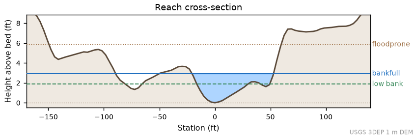

Figure 1: EASI cross section for Mink Brook.

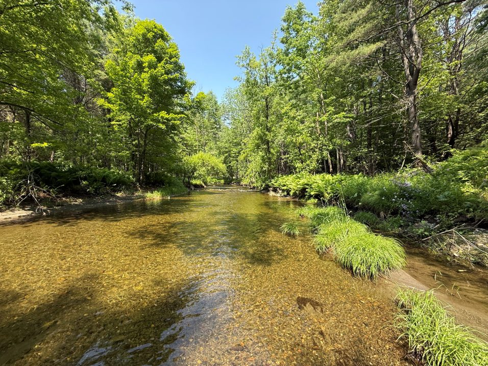

Figure 2: Mink Brook, New Hampshire.

**EASI** ECI 0.72 (Physical 0.78, Chemical 0.6, Biological 0.77). **SFARI** ECI 0.88 (Physical 0.84, Chemical 0.93, Biological 0.87).

Table 8: EASI and SFARI function scores at Mink Brook, on the 0 to 15 scale. An asterisk marks an expert override.

| Function | EASI rating | EASI score | SFARI score |
| --- | --- | --- | --- |
| Catchment hydrology | Good | 13 | 13.0 |
| Surface water storage | Fair | 8 | 12.0 |
| Reach inflow | Fair | 8 | 11.0 |
| Streamflow regime | Good | 13 | 14.5 |
| Low flow and baseflow dynamics | Good | 13 | 15.0 |
| High flow dynamics | Good * | 13 | 12.0 |
| Floodplain connectivity | Good * | 13 | 11.0 |
| Hyporheic connectivity | Good | 13 | 14.0 |
| Channel evolution | Good * | 13 | 12.0 |
| Channel and floodplain dynamics | Good | 13 | 11.5 |
| Sediment continuity | Fair | 8 | 12.0 |
| Light & thermal regime | Fair | 8 | 14.0 |
| Carbon processing | Fair | 8 | 14.0 |
| Nutrient cycling | Good | 13 | 14.0 |
| Water & soil quality | Poor | 3 | 15.0 |
| Habitat provision | Fair | 8 | 14.0 |
| Population support | Good | 13 | 15.0 |
| Community dynamics | Good | 13 | 12.0 |
| Watershed connectivity | Good | 13 | 11.0 |

*Functions marked with an asterisk were set by expert override to reflect field condition.*

### Cowart Creek, Texas

[figure not shown]

Figure 3: EASI cross section for Cowart Creek.

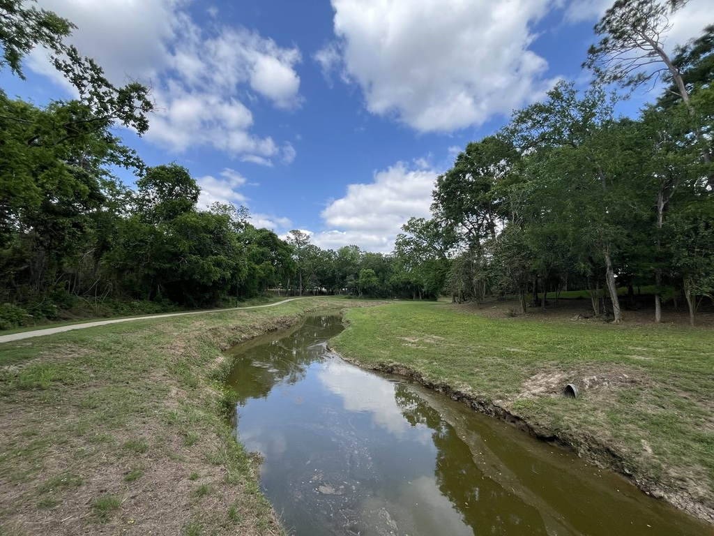

Figure 4: Cowart Creek, Texas, upstream view.

**EASI** ECI 0.42 (Physical 0.53, Chemical 0.34, Biological 0.4). **SFARI** ECI 0.15 (Physical 0.13, Chemical 0.15, Biological 0.18).

Table 9: EASI and SFARI function scores at Cowart Creek, on the 0 to 15 scale. An asterisk marks an expert override.

| Function | EASI rating | EASI score | SFARI score |
| --- | --- | --- | --- |
| Catchment hydrology | Fair | 8 | 6.0 |
| Surface water storage | Fair | 8 | 0.0 |
| Reach inflow | Poor | 3 | 2.0 |
| Streamflow regime | Good | 13 | 2.0 |
| Low flow and baseflow dynamics | Good | 13 | 3.5 |
| High flow dynamics | Poor | 3 | 1.0 |
| Floodplain connectivity | Good | 13 | 1.0 |
| Hyporheic connectivity | Good | 13 | 1.0 |
| Channel evolution | Poor | 3 | 1.0 |
| Channel and floodplain dynamics | Poor | 3 | 1.0 |
| Sediment continuity | Poor | 3 | 1.0 |
| Light & thermal regime | Poor | 3 | 2.0 |
| Carbon processing | Poor | 3 | 3.0 |
| Nutrient cycling | Poor | 3 | 2.0 |
| Water & soil quality | Fair | 8 | 3.0 |
| Habitat provision | Poor | 3 | 2.0 |
| Population support | Poor | 3 | 3.0 |
| Community dynamics | Poor | 3 | 3.0 |
| Watershed connectivity | Good | 13 | 4.0 |

### Marys Creek, Texas

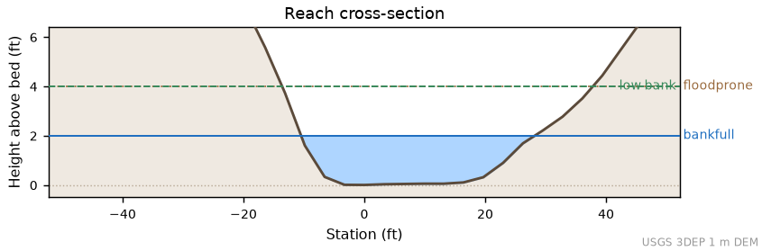

Figure 5: EASI cross section for Marys Creek.

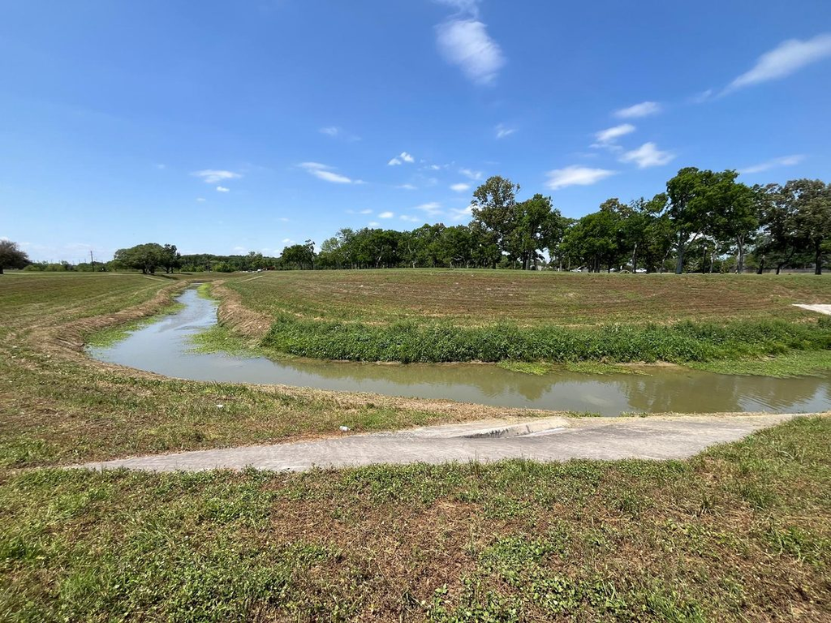

Figure 6: Marys Creek, Texas, upstream view.

**EASI** ECI 0.39 (Physical 0.47, Chemical 0.32, Biological 0.38). **SFARI** ECI 0.23 (Physical 0.24, Chemical 0.19, Biological 0.27).

Table 10: EASI and SFARI function scores at Mary’s Creek, on the 0 to 15 scale. An asterisk marks an expert override.

| Function | EASI rating | EASI score | SFARI score |
| --- | --- | --- | --- |
| Catchment hydrology | Poor | 3 | 7.0 |
| Surface water storage | Fair | 8 | 2.0 |
| Reach inflow | Poor | 3 | 2.0 |
| Streamflow regime | Good | 13 | 2.5 |
| Low flow and baseflow dynamics | Good | 13 | 6.5 |
| High flow dynamics | Poor | 3 | 13.0 |
| Floodplain connectivity | Good | 13 | 0.0 |
| Hyporheic connectivity | Fair | 8 | 2.0 |
| Channel evolution | Poor | 3 | 1.0 |
| Channel and floodplain dynamics | Poor | 3 | 1.0 |
| Sediment continuity | Poor | 3 | 1.0 |
| Light & thermal regime | Poor | 3 | 1.0 |
| Carbon processing | Poor | 3 | 6.0 |
| Nutrient cycling | Poor | 3 | 3.0 |
| Water & soil quality | Fair | 8 | 3.0 |
| Habitat provision | Poor | 3 | 5.0 |
| Population support | Poor | 3 | 6.0 |
| Community dynamics | Poor | 3 | 3.0 |
| Watershed connectivity | Good | 13 | 3.0 |

# 6 Validation

**NoteStatistics current as of 2026-09-16**

The statistics in this section were computed with the frozen criteria of September 2026 (method digest b2e3033116e3), from a fresh run of all 17 sites with service data pulled on 2026-09-16. Two cautions from that work: the dam inventory was read from a copy pulled on 2026-09-10 because the live service was down that day, and paired same-day requests in August returned different catchment-scale StreamCat components at one site. Small differences in the agreement statistics are within the noise of the underlying services. To refresh these results, re-run the site corpus and the build (`python scripts/build_docs.py --all`, network, about ten minutes).

Validation asks whether EASI estimates agree with independent observations of stream condition. We used the SFARI field assessments as the reference. SFARI is the Rapid tier of STAF and is based on focused fieldwork, so its results provide an independent, field-based measure of the same stream functions that EASI estimates from desktop data (David et al. In Review). Because the two methods share the same function list, we can compare them at three levels: the overall Ecosystem Condition Index, the three outcome sub-indices, and the individual functions.

## 6.1 Data and methods

EASI was run at each SFARI site using only the site coordinates. SFARI field results were taken from the SFARI verification dataset. Both methods report function scores on a 0 to 15 scale and report sub-indices and the Ecosystem Condition Index on a 0 to 1 scale, so the two are directly comparable without rescaling. We compared the methods with scatter plots against a one-to-one line, with the Pearson correlation and mean absolute difference, and with agreement on the three condition classes (Non-Functioning, Functioning-at-Risk, Functioning).

Table 11: Agreement between EASI and SFARI across the non-duplicate sites. Index comparisons use the 0 to 1 scale.

| Comparison | Pearson r | Mean abs diff |
| --- | --- | --- |
| Ecosystem Condition Index | 0.71 | 0.16 |
| Physical sub-index | 0.34 | 0.20 |
| Chemical sub-index | 0.65 | 0.15 |
| Biological sub-index | 0.66 | 0.17 |

## 6.2 Ecosystem Condition Index

Figure 7 compares the EASI and SFARI Ecosystem Condition Index across sites. Points near the one-to-one line indicate agreement.

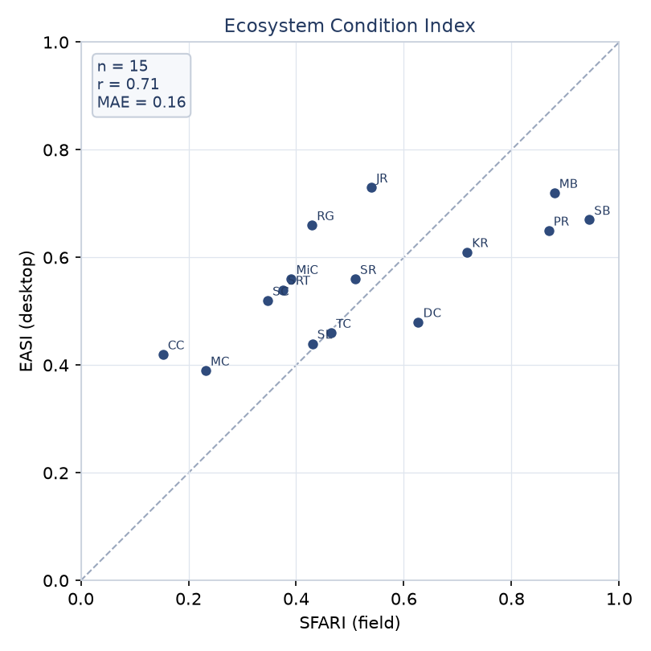

Figure 7: EASI and SFARI Ecosystem Condition Index across the verification sites. The dashed line is one-to-one.

## 6.3 Outcome sub-indices

Figure 8 compares the physical, chemical, and biological sub-indices.

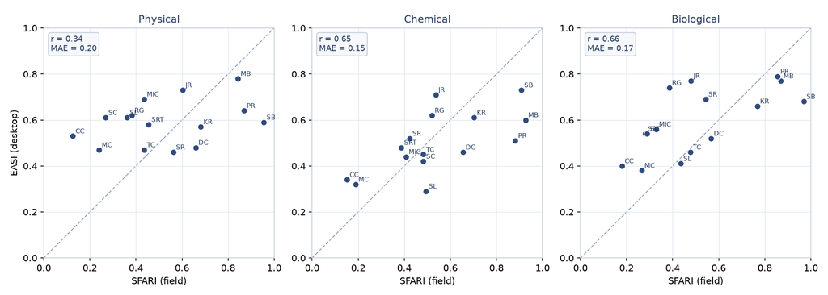

Figure 8: EASI and SFARI physical, chemical, and biological sub-indices.

## 6.4 Function-level agreement

Figure 9 summarizes agreement for each shared function. SFARI Planform change and EASI Bed composition and large wood have no counterpart in the other method, so nineteen of the twenty functions are compared.

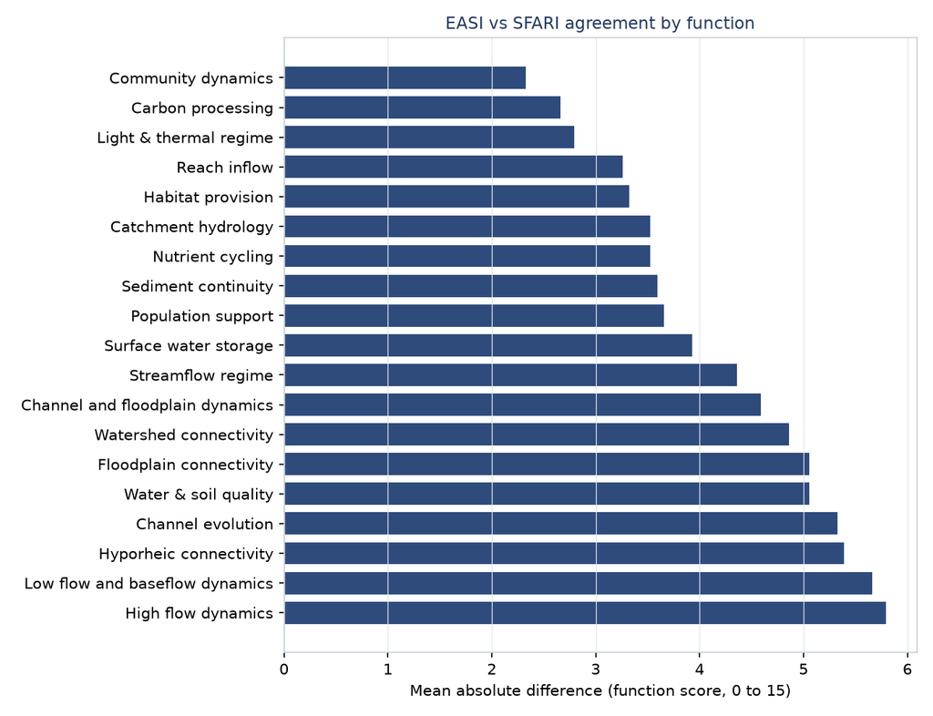

Figure 9: Mean absolute difference between EASI and SFARI function scores, by function, on the 0 to 15 scale.

## 6.5 Classification agreement

Table 12 shows how often EASI and SFARI place a site in the same condition class for the Ecosystem Condition Index.

Table 12: Agreement on Ecosystem Condition Index class across 15 sites. Exact agreement 8 of 15. Within one class 15 of 15.

| SFARI \ EASI | Non-Func. | At-Risk | Func. |
| --- | --- | --- | --- |
| Non-Func. | 1 | 3 | 0 |
| At-Risk | 0 | 6 | 1 |
| Func. | 0 | 3 | 1 |

## 6.6 Interpretation

EASI is a screening tool, so the goal of validation is not exact agreement with field results. The goal is to confirm that EASI separates streams in good condition from streams in poor condition and that it does so for the right reasons. The comparisons above should be read in that light. Where EASI and SFARI diverge, the difference often points to a function that depends on field observation, which is exactly where the override workflow and the higher STAF tiers add value.

# 7 Limitations

# 8 Summary

EASI is the Screening tier of STAF. It estimates the condition of wadeable streams across the conterminous United States from national data, organizes the results into physical, chemical, and biological outcomes, and reports an overall Ecosystem Condition Index. This document described how EASI is conceptualized, quantified, and applied, and it reported verification and validation against SFARI field results at sites that span the country. EASI ran end to end at every site and produced condition estimates that track the field assessments. The 2026-08 defensibility review anchored the metric thresholds to published sources where they exist and labeled the remaining screening judgments. Continued work will expand the validation dataset, examine regional thresholds, and extend the web application as additional national datasets become available.

# 9 References

Beechie, T. J., D. A. Sear, J. D. Olden, G. R. Pess, J. M. Buffington, H. Moir, P. Roni, and M. M. Pollock. 2010. Process-based principles for restoring river ecosystems. BioScience 60: 209-222.

Bieger, K., H. Rathjens, P. M. Allen, and J. G. Arnold. 2015. Development and evaluation of bankfull hydraulic geometry relationships for the physiographic regions of the United States. Journal of the American Water Resources Association 51 (3): 842-858.

David, G. C. L., D. E. Somerville, J. M. McCarthy, S. D. MacNeil, F. Fitzpatrick, R. Evans, and D. Wilson. 2021. Technical Guide for the Development, Evaluation, and Modification of Stream Assessment Methods for the Corps Regulatory Program. Washington, DC: U.S. Army Corps of Engineers.

David, G. C. L., L. M. Stepchinski, S. R. Wiest, and G. T. Menichino. In Review. Stream Functions Assessment and Rapid Index (SFARI). Technical Report, Ecosystem Management and Restoration Research Program. Vicksburg, MS: U.S. Army Engineer Research and Development Center.

Doyle, M. W., and F. D. Shields Jr. 2012. Compensatory mitigation for streams under the Clean Water Act: Reassessing science and redirecting policy. Journal of the American Water Resources Association 48 (3): 494-509.

Fenneman, N. M., and D. W. Johnson. 1946. Physical Divisions of the United States (map, 1:7,000,000). Reston, VA: U.S. Geological Survey.

Fischenich, J. C. 2006. Functional Objectives for Stream Restoration. EMRRP Technical Note SR-52. Vicksburg, MS: U.S. Army Corps of Engineers.

Harman, W., R. Starr, M. Carter, K. Tweedy, M. M. Clemmons, K. Suggs, and C. Miller. 2012. A Function-Based Framework for Stream Assessment and Restoration Projects. Washington, DC: U.S. Environmental Protection Agency.

Palmer, M. A., and J. D. Allan. 2006. Restoring rivers. Issues in Science and Technology 22 (2): 40-48.

Palmer, M. A., and S. Filoso. 2009. Restoration of ecosystem services for environmental markets. Science 325 (5940): 575-576.

Rosgen, D. L. 1996. Applied River Morphology. Pagosa Springs, CO: Wildland Hydrology.

Stepchinski, L., S. K. McKay, and G. T. Menichino. 2025a. Review of Stream Assessments for Evaluating Ecological Impacts and Benefits. Technical Note, Ecosystem Management and Restoration Research Program. Vicksburg, MS: U.S. Army Engineer Research and Development Center.

Stepchinski, L. M., S. K. McKay, A. E. Harris, and G. T. Menichino. 2025b. A review of stream assessment methods in the United States. Journal of the American Water Resources Association. https://doi.org/10.1111/1752-1688.70056.

Stepchinski, L. M., S. K. McKay, and G. T. Menichino. In Review a. A Synthesis and Inventory of Stream Functions. River Research and Applications.

Stepchinski, L. M., S. K. McKay, and G. T. Menichino. In Review b. A Tiered Approach to Developing Function-Based Stream Assessments. Journal of the American Water Resources Association.

Stepchinski, L. M., and G. T. Menichino. In Review. Ecosystem Assessment Screening Index (EASI). ERDC/TN EMRRP-26-DRAFT. Vicksburg, MS: U.S. Army Engineer Research and Development Center.

Wohl, E., B. P. Bledsoe, R. B. Jacobson, N. L. Poff, S. L. Rathburn, D. M. Walters, and A. C. Wilcox. 2015. The natural sediment regime in rivers: Broadening the foundation for ecosystem management. BioScience 65 (4): 358-371.

## 10 Appendix: full site comparison

Table 13 reports every verification site with its EASI and SFARI Ecosystem Condition Index and sub-indices. Duplicated SFARI rows are marked.

Table 13: Full EASI and SFARI comparison for every verification site (P/C/B = physical/chemical/biological sub-index).

| Site | State | EASI ECI | SFARI ECI | EASI P/C/B | SFARI P/C/B | Note |
| --- | --- | --- | --- | --- | --- | --- |
| Slade Brook | NH | 0.67 | 0.94 | 0.59/0.73/0.68 | 0.96/0.91/0.97 |  |
| Mink Brook | NH | 0.72 | 0.88 | 0.78/0.6/0.77 | 0.84/0.93/0.87 |  |
| Poudre River | CO | 0.65 | 0.87 | 0.64/0.51/0.79 | 0.87/0.88/0.86 |  |
| Kenduskeag River | ME | 0.61 | 0.72 | 0.57/0.61/0.66 | 0.68/0.70/0.77 |  |
| Durden Creek | MS | 0.48 | 0.63 | 0.48/0.46/0.52 | 0.66/0.65/0.57 |  |
| Jemez River | NM | 0.73 | 0.54 | 0.73/0.71/0.77 | 0.60/0.54/0.48 |  |
| Sangamon River | IL | 0.56 | 0.51 | 0.46/0.52/0.69 | 0.56/0.42/0.54 |  |
| Trail Creek | GA | 0.46 | 0.46 | 0.47/0.45/0.46 | 0.44/0.48/0.48 |  |
| St Lucie River | FL | 0.44 | 0.43 | 0.61/0.29/0.41 | 0.36/0.49/0.43 |  |
| Rio Grande | NM | 0.66 | 0.43 | 0.62/0.62/0.74 | 0.38/0.52/0.39 |  |
| Middle Creek | TN | 0.56 | 0.39 | 0.69/0.44/0.56 | 0.44/0.41/0.33 |  |
| Mountain Creek | TN | 0.54 | 0.39 | 0.56/0.53/0.54 | 0.44/0.41/0.33 | SFARI dup of MiC |
| Tributary to Sugar River | NH | 0.54 | 0.37 | 0.58/0.48/0.54 | 0.46/0.39/0.28 |  |
| Shoal Creek | TN | 0.52 | 0.35 | 0.61/0.42/0.54 | 0.27/0.48/0.29 |  |
| Mary’s Creek | TX | 0.39 | 0.23 | 0.47/0.32/0.38 | 0.24/0.19/0.27 |  |
| Gila River | NM | 0.67 | 0.23 | 0.59/0.68/0.74 | 0.24/0.19/0.27 | SFARI dup of MC |
| Cowart Creek | TX | 0.42 | 0.15 | 0.53/0.34/0.4 | 0.13/0.15/0.18 |  |